# Effects of Used Cars Year, Seller, Transmission, Owner and Maximum Power on Their Selling Prices

## by Tobi Adegoke

## Investigation Overview

> In this investigation, I want to look at the features of used cars in some states in USA that would be used to predict the selling prices of the used cars. my main focus are the year the cars was bought, the owner type, maximum power of the car, the car transmission and seller type.

## Dataset Overview

> The Dataset used is a Used_Cars Dataset gathered from Kaggle website. The Dataset contains 7906 Feature values and 18 feature labels of Used Cars in some state in USA. during pre wrangling, I removed rows containing Test_Drive_Cars from the dataset, grouped year and fill it undeer a new added label named 'year_group', then dropped the year column. Also I converted from object datatypes to category datatype of some columns and extract first words from owner column. I also renamed Trustmark_Dealer to Dealer in seller_type column. this reshaped the dataset to 7901 rows and 11 columns with 5 numerical variables and 6 categorical variables.

## plotting the distribution of the selling price

it is right skewed, majority of the cars are selling at low price. below $2,500,000

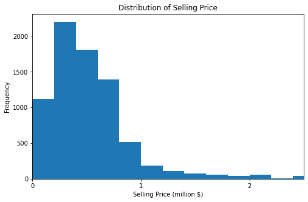

## Relationship between maximum power and selling prices of used cars

selling price and maximum power are strongly positive correlated, higher maximum power of used cars sells at higher price while lower maximum power sells at lower prices

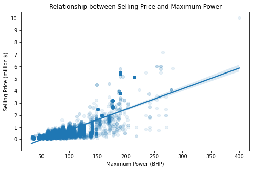

## Relationship between seller type and selling price, transmission and selling price of used cars

cars sells by Dealer are more expensive also automatic cars are more expensive that cars sells by Individual and manual cars

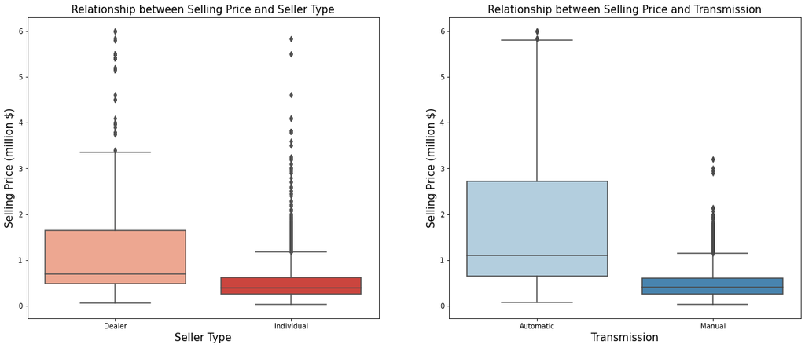

## Relationship between Owner and selling price, Year and selling price of used cars

The plot of the owner against selling price look similar to the plot of year against selling price. This implies that as the car gets older, and being move from first owner to second owner till fourth, the selling price decreases.

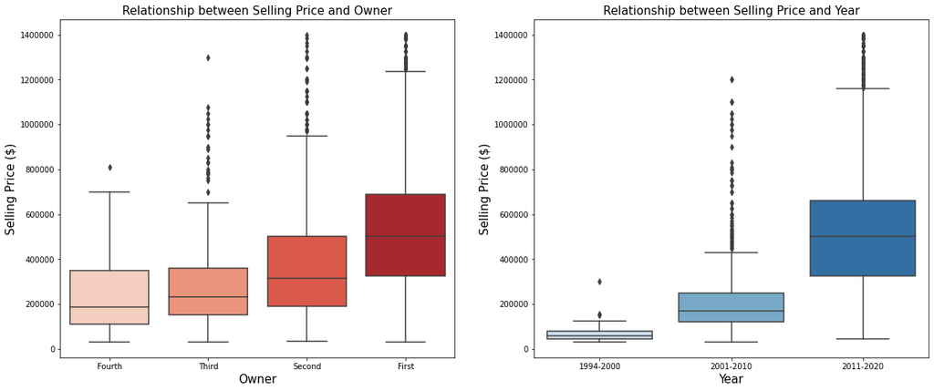

## the relationship between owner, selling price and year

Recent year cars are more expensive than older year cars irrespective of the owner as it can been seen from the below plot

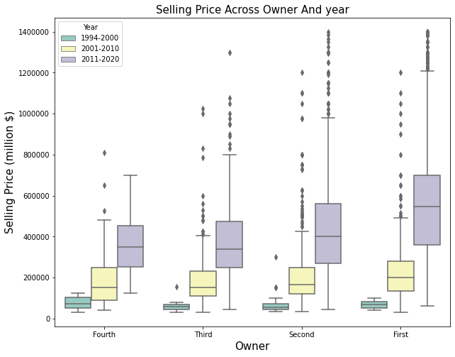

## the relationship between maximum power, selling price and transmission

Automatics cars are most espensive than Manual cars even across maximum power of the cars.

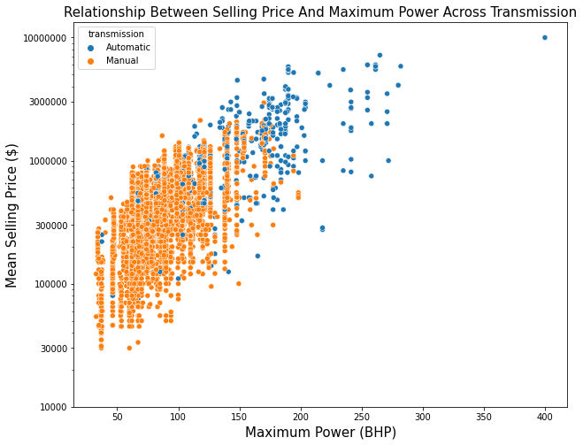

## the relationship between maximum power, selling price and year

the recent the used cars, the expensive the cars selling price.

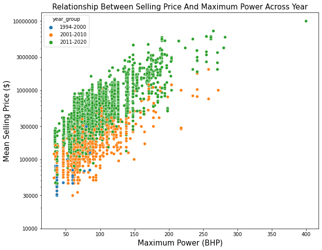

## the relationship between maximum power, selling price and owner

first owner used cars are more expensive than second owner used cars and son on.

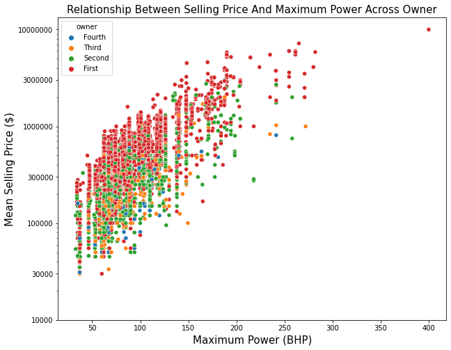